# Biostatistical Computing, PHC 6068

Linear Mixed Model

Zhiguang Huo (Caleb)

Wednesday October 27, 2021

# From linear model to linear mixed model

- Linear model:
  - Subjects are independent.
  - Cannot handle missing date (missing in Y).

$$Y = X^\top\beta + \varepsilon$$

- Linear mixed model:
  - Account for correlated structure between subjects.
  - Can accommodate missing data (missing in Y).

# voice pitch data

```r
d = read.csv("https://caleb-huo.github.io/teaching/data/politeness/politeness_data.csv")
str(d)
```

```
## 'data.frame':    84 obs. of  5 variables:
##  $ subject  : chr  "F1" "F1" "F1" "F1" ...
##  $ gender   : chr  "F" "F" "F" "F" ...
##  $ scenario : int  1 1 2 2 3 3 4 4 5 5 ...
##  $ attitude : chr  "pol" "inf" "pol" "inf" ...
##  $ frequency: num  213 204 285 260 204 ...
```

```r
d$attitude <- as.factor(d$attitude)
d$scenario0 <- as.factor(d$scenario)
```

- subject: (6 subjects)
- gender: (F/M)
- scenario: different scenario (7 categories)
- attitude:
  - inf: informal situations (e.g., explaining to a friend why you’re late)
  - pol: politeness (e.g., giving an excuse for being late to a professor)
- frequency: outcome variable, frequency of voice pitch

# voice pitch data

```r
head(d)
```

```
##   subject gender scenario attitude frequency scenario0
## 1      F1      F        1      pol     213.3         1
## 2      F1      F        1      inf     204.5         1
## 3      F1      F        2      pol     285.1         2
## 4      F1      F        2      inf     259.7         2
## 5      F1      F        3      pol     203.9         3
## 6      F1      F        3      inf     286.9         3
```

```r
with(d, table(subject, gender))
```

```
##        gender
## subject  F  M
##      F1 14  0
##      F2 14  0
##      F3 14  0
##      M3  0 14
##      M4  0 14
##      M7  0 14
```

```r
which(apply(d,1,function(x) any(is.na(x)))) ## one subject contails missing data (missing outcome variable)
```

```
## [1] 39
```

# visualize the data

```r
library(tidyverse)
```

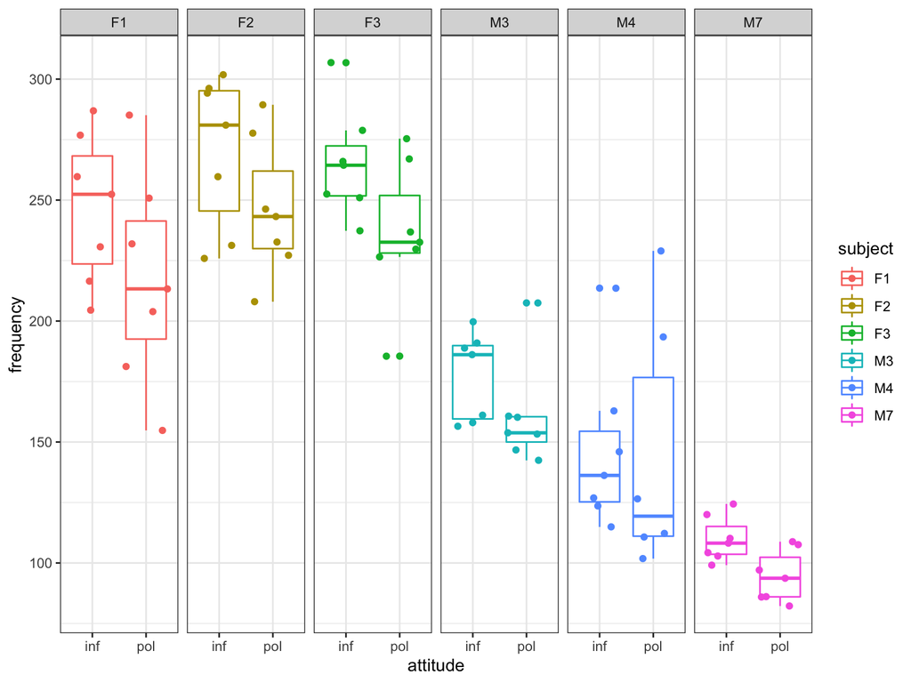

```r
ggplot(aes(attitude, frequency, color = subject), data=d) + facet_grid(~subject) + geom_boxplot() + geom_jitter() + theme_bw()
```

# Fit linear model

- Outcome variable: pitch (frequency)
- primary predictor: attitude (politeness)
- $\varepsilon$: deviations from our predictions due to random factors that we cannot control experimentally

$$frequency \sim \mu + politeness + \varepsilon$$

# Linear model in R

```r
lmFit <- lm(frequency ~ attitude, data = d)
summary(lmFit)
```

```
##
## Call:
## lm(formula = frequency ~ attitude, data = d)
##
## Residuals:
##      Min       1Q   Median       3Q      Max
## -103.488  -62.122    9.044   51.178  105.044
##
## Coefficients:
##             Estimate Std. Error t value Pr(>|t|)
## (Intercept)   202.59      10.08  20.107   <2e-16 ***
## attitudepol   -18.23      14.34  -1.272    0.207
## ---
## Signif. codes:  0 '***' 0.001 '**' 0.01 '*' 0.05 '.' 0.1 ' ' 1
##
## Residual standard error: 65.3 on 81 degrees of freedom
##   (1 observation deleted due to missingness)
## Multiple R-squared:  0.01958,    Adjusted R-squared:  0.007475
## F-statistic: 1.618 on 1 and 81 DF,  p-value: 0.2071
```

Note:

- $1$ observation deleted due to missingness
- attitude is not a significant predictor

# Problem with linear model

$$frequency_{ijk} \sim \mu + politeness_{k} + \varepsilon_{ijk},$$
where $i$ is a subject index, $j$ is a scenario index, and $k$ is the politeness index.

Dependent structure:

- Multiple responses from the same subject $i$ cannot be regarded as independent from each other.
  - $frequency_{i1k}, frequency_{i2k}, \ldots, frequency_{iJk}$ should be correlated

# data independence

```r
subj_spread <- d %>% spread(attitude, frequency)
subj_spread$scenario0 <- as.factor(subj_spread$scenario)
head(subj_spread)
```

```
##   subject gender scenario scenario0   inf   pol
## 1      F1      F        1         1 204.5 213.3
## 2      F1      F        2         2 259.7 285.1
## 3      F1      F        3         3 286.9 203.9
## 4      F1      F        4         4 276.8 250.8
## 5      F1      F        5         5 252.4 231.9
## 6      F1      F        6         6 230.7 181.2
```

# Subject dependence

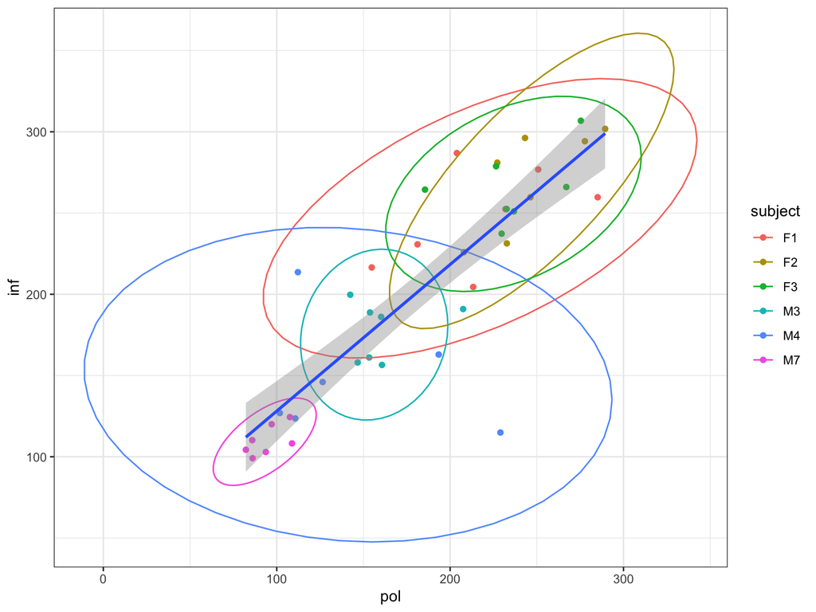

```r
ggplot(data=subj_spread, aes(pol, inf)) + theme_bw() +
  geom_point(aes(col=subject)) +
  stat_ellipse(aes(col=subject)) +
  geom_smooth(method="lm")
```

# Random effects:

- Fixed effects:
  - Categorical variables with well-defined categories (e.g., gender, race)
- Random effects:
  - We only sample a subset of the entire population
    - The 6 participants in the data are a subset of the entire population
    - Each participant has repeated measurement.
    - The “subject” effect $\alpha_i$ for subject $i$ is best thought of as random: $\alpha_i \sim N(0, \sigma_0^2)$

When to use random effects?

- A “subject” effect is random if we can think of the levels we observe for that subject to be samples from a larger population.
- Example: we are investigating the GPA of UF undergraduate students by surveying a small group of students.
  - Gender and race are considered fixed effect since their categories are well-defined.
  - Department is considered as random effect, since our survey may not covering all departments in UF.

# Mixed model

- Linear model is “fixed-effects only” model
  - one or more fixed effects
  - a general error term $\varepsilon$
  - error term is considered no structure.
- Mixed model is a mixture of fixed effect and random effect

# Benefit of random effect models

- Allows us to resolve this non-independence data structure for each subject
- Allows missing data (missing outcome variable)

# Fit linear mixed model in R

- In R, lmer() function in lme4 package will do the job

```r
alm <- lm(frequency ~ attitude, data = d)
suppressMessages(library(lme4))
suppressMessages(library(lmerTest)) ## this package helps provide a p-value
```

- We have to specify random effect when using lmer funciton.

# Fit linear mixed model in R

```r
rs_subj_reml = lmer(frequency ~ attitude + (1 | subject), data = d)
summary(rs_subj_reml)
```

```
## Linear mixed model fit by REML. t-tests use Satterthwaite's method [
## lmerModLmerTest]
## Formula: frequency ~ attitude + (1 | subject)
##    Data: d
##
## REML criterion at convergence: 804.7
##
## Scaled residuals:
##     Min      1Q  Median      3Q     Max
## -2.2953 -0.6018 -0.2005  0.4774  3.1772
##
## Random effects:
##  Groups   Name        Variance Std.Dev.
##  subject  (Intercept) 3982     63.10
##  Residual              851     29.17
## Number of obs: 83, groups:  subject, 6
##
## Fixed effects:
##             Estimate Std. Error      df t value Pr(>|t|)
## (Intercept)  202.588     26.151   5.150   7.747 0.000501 ***
## attitudepol  -19.376      6.407  76.003  -3.024 0.003399 **
## ---
## Signif. codes:  0 '***' 0.001 '**' 0.01 '*' 0.05 '.' 0.1 ' ' 1
##
## Correlation of Fixed Effects:
##             (Intr)
## attitudepol -0.121
```

# How to write the linear mixed model mathmatically

$$Y_{ijk} = \mu + \gamma \mathbb{I}(k=pol) + \alpha_i + \varepsilon_{ijk}$$

- $i$: subject index
- $j$: scenario index
- $k$: attitude index
- $\mu$: intercept
- $\gamma$: attitude coefficient of the polite group
- $\alpha_i \sim N(0, \sigma^2_\alpha)$: random effect for the $i^{th}$ subject
- $\varepsilon_{ijk} \sim N(0, \sigma^2)$:
- Total error term: $\alpha_i + \varepsilon_{ijk}$
  - so the error for $i1k$ and $i2k$ are dependent
- If there is no $\alpha_i$, the above model will reduce to linear regression model.

# Further explore rs_subj_reml

```r
coef(alm)
```

```
## (Intercept) attitudepol
##    202.5881    -18.2320
```

```r
coef(rs_subj_reml)
```

```
## $subject
##    (Intercept) attitudepol
## F1    241.1352   -19.37584
## F2    266.8920   -19.37584
## F3    259.5540   -19.37584
## M3    179.0262   -19.37584
## M4    155.6906   -19.37584
## M7    113.2306   -19.37584
##
## attr(,"class")
## [1] "coef.mer"
```

```r
AIC(rs_subj_reml)
```

```
## [1] 812.7023
```

# Further explore rs_subj_reml

- Subject total intercept:
  $$\mu + \alpha_i$$
  - vary among different subjects
- Attitude effect
  $$\beta_j$$
  - same among different subjects

# Random Intercepts

- linear model
  $$frequency \sim 1 + politeness + \varepsilon$$
- linear model with random effect (random intercept)
  $$frequency \sim 1 + politeness +(1|subject) + \varepsilon$$
  $(1|subject)$ is the R syntax for a random intercept.
- intercepts are different for each subject
- “$1$” stands for the intercept in R
- this formula indicates multiple responses per subject
- resolves the non-independence multiple responses by the same subject
- the formula still contains a general error term $\varepsilon$

# Visualization for the random intercept

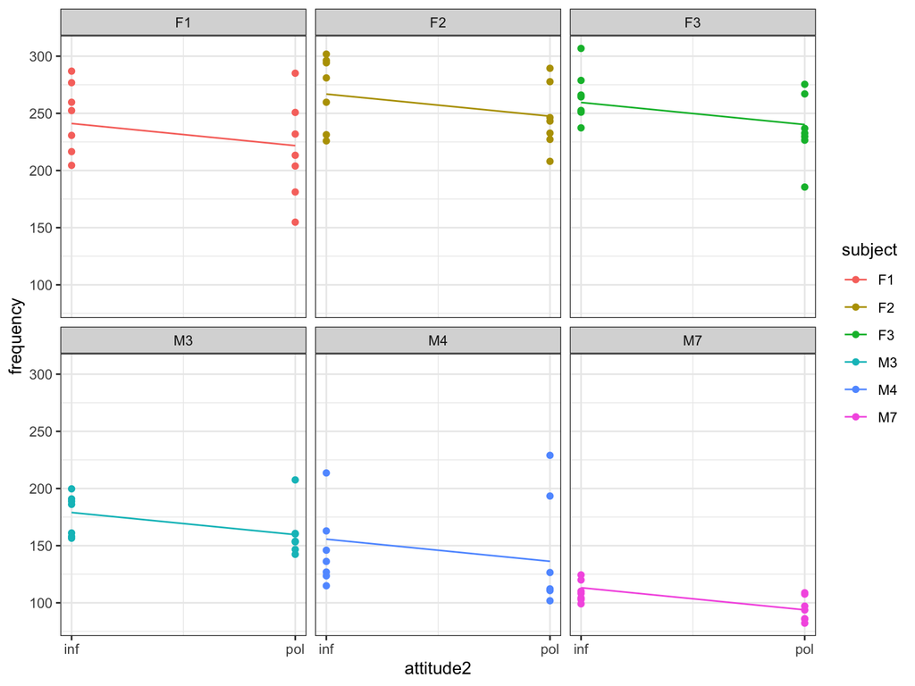

# Fit linear mixed model in R (REML = FALSE)

```r
rs_subj_ml = lmer(frequency ~ attitude + (1 | subject), REML = FALSE, data = d)
summary(rs_subj_ml)
```

```
## Linear mixed model fit by maximum likelihood . t-tests use Satterthwaite's
##   method [lmerModLmerTest]
## Formula: frequency ~ attitude + (1 | subject)
##    Data: d
##
##      AIC      BIC   logLik deviance df.resid
##    826.5    836.2   -409.3    818.5       79
##
## Scaled residuals:
##     Min      1Q  Median      3Q     Max
## -2.3067 -0.6051 -0.2042  0.4793  3.1931
##
## Random effects:
##  Groups   Name        Variance Std.Dev.
##  subject  (Intercept) 3308.7   57.52
##  Residual              839.9   28.98
## Number of obs: 83, groups:  subject, 6
##
## Fixed effects:
##             Estimate Std. Error      df t value Pr(>|t|)
## (Intercept)  202.588     23.905   6.214   8.475 0.000122 ***
## attitudepol  -19.372      6.365  77.003  -3.043 0.003199 **
## ---
## Signif. codes:  0 '***' 0.001 '**' 0.01 '*' 0.05 '.' 0.1 ' ' 1
##
## Correlation of Fixed Effects:
##             (Intr)
## attitudepol -0.131
```

# REML option

REML represents restricted maximum likelihood

- if REML=FALSE, maximum likelihood estimation will be used (biased estimation)
- if REML=TRUE, its estimation does not base on a maximum likelihood, but instead uses a likelihood function calculated from a transformed set of data (unbiased estimation)

# Compare to linear model

```r
summary(lm(frequency ~ attitude, data = d))
```

```
##
## Call:
## lm(formula = frequency ~ attitude, data = d)
##
## Residuals:
##      Min       1Q   Median       3Q      Max
## -103.488  -62.122    9.044   51.178  105.044
##
## Coefficients:
##             Estimate Std. Error t value Pr(>|t|)
## (Intercept)   202.59      10.08  20.107   <2e-16 ***
## attitudepol   -18.23      14.34  -1.272    0.207
## ---
## Signif. codes:  0 '***' 0.001 '**' 0.01 '*' 0.05 '.' 0.1 ' ' 1
##
## Residual standard error: 65.3 on 81 degrees of freedom
##   (1 observation deleted due to missingness)
## Multiple R-squared:  0.01958,    Adjusted R-squared:  0.007475
## F-statistic: 1.618 on 1 and 81 DF,  p-value: 0.2071
```

Without adjusting for random effect, attitude won’t be a significant predictor.

# Alternative ways to get p-values (likelihood ratio test)

- likelihood ratio test: comparing full model and reduced model
- get the p-value for reduced variable
- need to use REML = FALSE, otherwise, anova will re-fit the reml model such that REML = FALSE.

```r
rs_subj_ml = lmer(frequency ~ attitude + (1 | subject), REML = FALSE, data = d)
rs_null_ml = lmer(frequency ~ 1 + (1 | subject), REML = FALSE, data = d)

anova(rs_null_ml, rs_subj_ml)
```

```
## Data: d
## Models:
## rs_null_ml: frequency ~ 1 + (1 | subject)
## rs_subj_ml: frequency ~ attitude + (1 | subject)
##            npar    AIC    BIC  logLik deviance  Chisq Df Pr(>Chisq)
## rs_null_ml    3 833.25 840.51 -413.62   827.25
## rs_subj_ml    4 826.51 836.18 -409.25   818.51 8.7444  1   0.003106 **
## ---
## Signif. codes:  0 '***' 0.001 '**' 0.01 '*' 0.05 '.' 0.1 ' ' 1
```

# Add covariates

```r
summary(lmer(frequency ~ attitude + gender +  (1 | subject), data = d))
```

```
## Linear mixed model fit by REML. t-tests use Satterthwaite's method [
## lmerModLmerTest]
## Formula: frequency ~ attitude + gender + (1 | subject)
##    Data: d
##
## REML criterion at convergence: 786.7
##
## Scaled residuals:
##     Min      1Q  Median      3Q     Max
## -2.3619 -0.5305 -0.1724  0.4647  3.2260
##
## Random effects:
##  Groups   Name        Variance Std.Dev.
##  subject  (Intercept) 603.9    24.57
##  Residual             850.9    29.17
## Number of obs: 83, groups:  subject, 6
##
## Fixed effects:
##             Estimate Std. Error       df t value Pr(>|t|)
## (Intercept)  256.691     15.226    4.378  16.859 3.78e-05 ***
## attitudepol  -19.410      6.407   76.018  -3.030  0.00334 **
## genderM     -108.205     21.063    4.009  -5.137  0.00677 **
## ---
## Signif. codes:  0 '***' 0.001 '**' 0.01 '*' 0.05 '.' 0.1 ' ' 1
##
## Correlation of Fixed Effects:
##             (Intr) atttdp
## attitudepol -0.210
## genderM     -0.692  0.004
```

# Randon intercept and random slope

- Random intercept only:

$$Y_{ijk} = (\mu + \alpha_i) + \gamma \mathbb{I}(k=pol) + \varepsilon_{ijk}$$

- Random intercept and random slope:

$$Y_{ijk} = (\mu + \alpha_i) + (\gamma + \eta_i) \mathbb{I}(k=pol) + \varepsilon_{ijk}$$

- $(\alpha_i, \eta_i)^\top \sim N(0, \Sigma)$: random intercept and random slope for the $i^{th}$ subject
- $\varepsilon_{ijk} \sim N(0, \sigma^2)$:

# Visualization for the random slope

```
## boundary (singular) fit: see ?isSingular
```

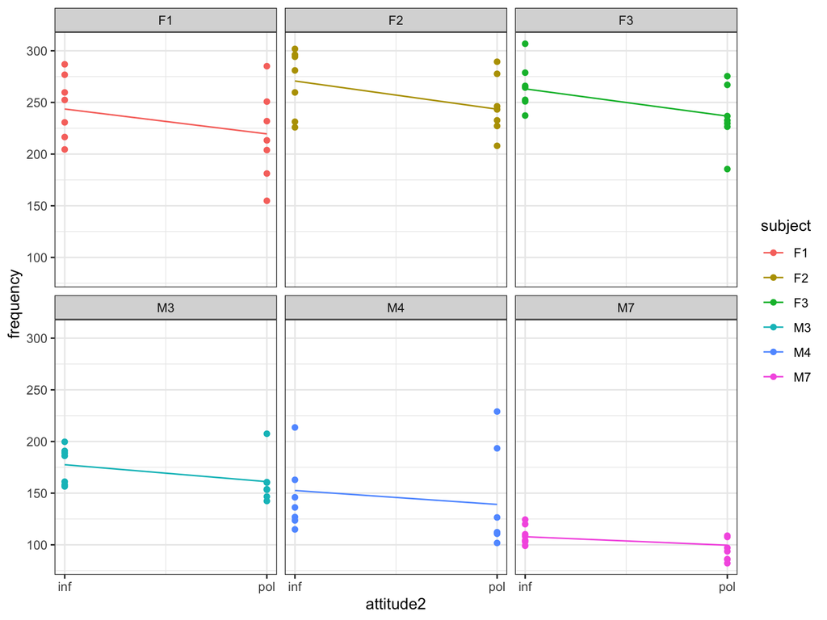

# Random Slopes in R

```r
politeness.model.rs = lmer(frequency ~  attitude + gender + (1 + attitude | subject), REML = FALSE, data = d)
```

```
## boundary (singular) fit: see ?isSingular
```

```r
summary(politeness.model.rs)
```

```
## Linear mixed model fit by maximum likelihood . t-tests use Satterthwaite's
##   method [lmerModLmerTest]
## Formula: frequency ~ attitude + gender + (1 + attitude | subject)
##    Data: d
##
##      AIC      BIC   logLik deviance df.resid
##    820.3    837.2   -403.2    806.3       76
##
## Scaled residuals:
##     Min      1Q  Median      3Q     Max
## -2.3848 -0.5270 -0.2221  0.5179  3.2462
##
## Random effects:
##  Groups   Name        Variance Std.Dev. Corr
##  subject  (Intercept) 359.95   18.972
##           attitudepol   1.57    1.253   1.00
##  Residual             839.41   28.973
## Number of obs: 83, groups:  subject, 6
##
## Fixed effects:
##             Estimate Std. Error       df t value Pr(>|t|)
## (Intercept)  257.503     12.396    6.274  20.773 5.06e-07 ***
## attitudepol  -19.408      6.384   63.951  -3.040 0.003423 **
## genderM     -109.829     17.167    6.021  -6.398 0.000677 ***
## ---
## Signif. codes:  0 '***' 0.001 '**' 0.01 '*' 0.05 '.' 0.1 ' ' 1
##
## Correlation of Fixed Effects:
##             (Intr) atttdp
## attitudepol -0.205
## genderM     -0.692  0.004
## optimizer (nloptwrap) convergence code: 0 (OK)
## boundary (singular) fit: see ?isSingular
```

# Random Slopes in R

```r
coef(politeness.model.rs)
```

```
## $subject
##    (Intercept) attitudepol   genderM
## F1    244.1807   -20.28814 -109.8295
## F2    266.1358   -18.83824 -109.8295
## F3    259.8311   -19.25459 -109.8295
## M3    283.4821   -17.69271 -109.8295
## M4    263.7729   -18.99429 -109.8295
## M7    227.6144   -21.38216 -109.8295
##
## attr(,"class")
## [1] "coef.mer"
```

# Is random slope necessary

```r
rs_gen_subjscene_con_reml = lmer(frequency ~ attitude + gender + (1 + attitude |
    subject), REML = TRUE, data = d)
```

```
## boundary (singular) fit: see ?isSingular
```

```r
rs_gen_subjscene_reml = lmer(frequency ~ attitude + gender + (1 | subject), REML = TRUE, data = d)

anova(rs_gen_subjscene_reml, rs_gen_subjscene_con_reml)
```

```
## refitting model(s) with ML (instead of REML)
```

```
## Data: d
## Models:
## rs_gen_subjscene_reml: frequency ~ attitude + gender + (1 | subject)
## rs_gen_subjscene_con_reml: frequency ~ attitude + gender + (1 + attitude | subject)
##                           npar    AIC    BIC  logLik deviance  Chisq Df
## rs_gen_subjscene_reml        5 816.34 828.43 -403.17   806.34
## rs_gen_subjscene_con_reml    7 820.31 837.24 -403.15   806.31 0.0282  2
##                           Pr(>Chisq)
## rs_gen_subjscene_reml
## rs_gen_subjscene_con_reml      0.986
```

- it appears that we don’t need to include random slope for condition in the model, because the likelihood ratio test is not significant
- however, others would argue that we should keep our models maximal

# Beyond linear mixed model (optional)

If the outcome variable is

- Continuous: use a linear regression model with mixed effects
- Binary: use a logistic regression model with mixed effects
- Count: use a Poisson/negative binomial regression model with mixed effects

Function lmer is used to fit linear mixed models, function glmer is used to fit generalized (non-Gaussian) linear mixed models.

# Longitudinal data

- Longitudinal data are repeated measures data in which the observations are taken over time.
- We wish to characterize the response over time within subjects and the variation in the time trends between subjects.

# Longitudinal data – sleep study

```r
sleepStudy <- read.table("https://caleb-huo.github.io/teaching/data/sleep/sleepstudy.txt", header=T, row.names = 1)
sleepStudy$Subject <- as.factor(sleepStudy$Subject)

head(sleepStudy, n=10)
```

```
##    Reaction Days Subject
## 1  249.5600    0     308
## 2  258.7047    1     308
## 3  250.8006    2     308
## 4  321.4398    3     308
## 5  356.8519    4     308
## 6  414.6901    5     308
## 7  382.2038    6     308
## 8  290.1486    7     308
## 9  430.5853    8     308
## 10 466.3535    9     308
```

```r
str(sleepStudy)
```

```
## 'data.frame':    180 obs. of  3 variables:
##  $ Reaction: num  250 259 251 321 357 ...
##  $ Days    : int  0 1 2 3 4 5 6 7 8 9 ...
##  $ Subject : Factor w/ 18 levels "308","309","310",..: 1 1 1 1 1 1 1 1 1 1 ...
```

# Sleep deprivation data

- This laboratory experiment measured the effect of sleep deprivation on cognitive performance.
- There were 18 subjects, chosen from the population of interest (long-distance truck drivers), in the 10 day trial. These subjects were restricted to 3 hours sleep per night during the trial.
- On each day of the trial each subject’s reaction time was measured. The reaction time shown here is the average of several measurements.
- These data are balanced in that each subject is measured the same number of times and on the same occasions.

# Data exploratory

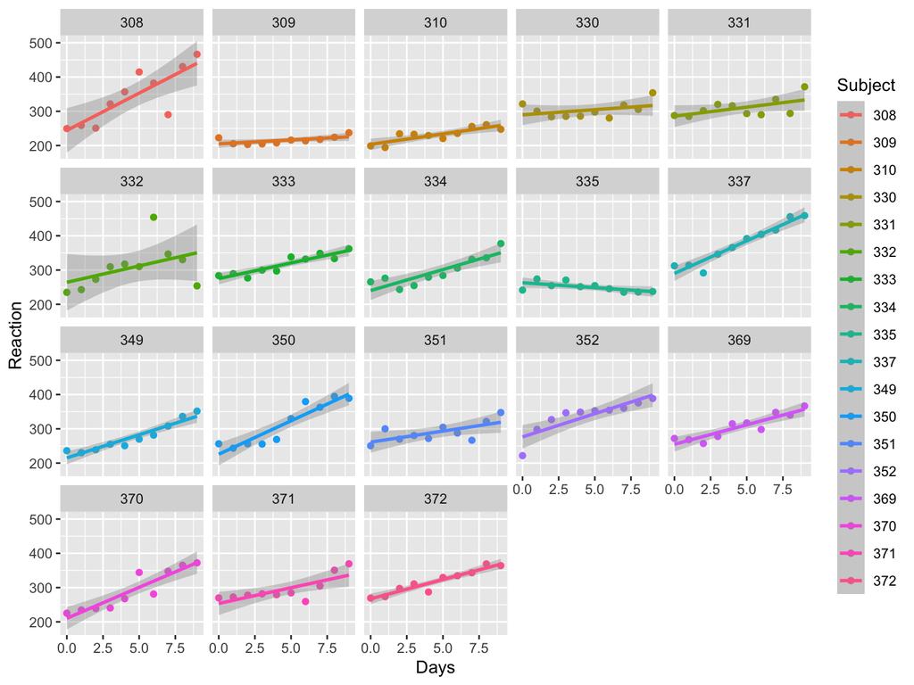

```r
ggplot(aes(Days, Reaction, col=Subject), data = sleepStudy) + geom_point() + geom_smooth(method="lm") + facet_wrap(~Subject)
```

# Fit linear mixed model in R

- Examine the relationship of Reaction time with respect to Days (slope)
- Each subject has repeated measurement of Reaction time
- Consider subject specific random intercept only

```r
fm1 <- lmer(Reaction ~ Days + (1|Subject), sleepstudy)
summary(fm1)
```

```
## Linear mixed model fit by REML. t-tests use Satterthwaite's method [
## lmerModLmerTest]
## Formula: Reaction ~ Days + (1 | Subject)
##    Data: sleepstudy
##
## REML criterion at convergence: 1786.5
##
## Scaled residuals:
##     Min      1Q  Median      3Q     Max
## -3.2257 -0.5529  0.0109  0.5188  4.2506
##
## Random effects:
##  Groups   Name        Variance Std.Dev.
##  Subject  (Intercept) 1378.2   37.12
##  Residual              960.5   30.99
## Number of obs: 180, groups:  Subject, 18
##
## Fixed effects:
##             Estimate Std. Error       df t value Pr(>|t|)
## (Intercept) 251.4051     9.7467  22.8102   25.79   <2e-16 ***
## Days         10.4673     0.8042 161.0000   13.02   <2e-16 ***
## ---
## Signif. codes:  0 '***' 0.001 '**' 0.01 '*' 0.05 '.' 0.1 ' ' 1
##
## Correlation of Fixed Effects:
##      (Intr)
## Days -0.371
```

# Fit linear mixed model in R

- Examine the relationship of Reaction time with respect to Days (slope)
- Each subject has repeated measurement of Reaction time
- Consider both subject specific random intercept and subject specific random slope

```r
fm1 <- lmer(Reaction ~ Days + (1 + Days|Subject), sleepstudy)
#fm1 <- lmer(Reaction ~ Days + (Days|Subject), sleepstudy) ## same as this one
summary(fm1)
```

```
## Linear mixed model fit by REML. t-tests use Satterthwaite's method [
## lmerModLmerTest]
## Formula: Reaction ~ Days + (1 + Days | Subject)
##    Data: sleepstudy
##
## REML criterion at convergence: 1743.6
##
## Scaled residuals:
##     Min      1Q  Median      3Q     Max
## -3.9536 -0.4634  0.0231  0.4634  5.1793
##
## Random effects:
##  Groups   Name        Variance Std.Dev. Corr
##  Subject  (Intercept) 612.10   24.741
##           Days         35.07    5.922   0.07
##  Residual             654.94   25.592
## Number of obs: 180, groups:  Subject, 18
##
## Fixed effects:
##             Estimate Std. Error      df t value Pr(>|t|)
## (Intercept)  251.405      6.825  17.000  36.838  < 2e-16 ***
## Days          10.467      1.546  17.000   6.771 3.26e-06 ***
## ---
## Signif. codes:  0 '***' 0.001 '**' 0.01 '*' 0.05 '.' 0.1 ' ' 1
##
## Correlation of Fixed Effects:
##      (Intr)
## Days -0.138
```

# coef

```r
coef(fm1)
```

```
## $Subject
##     (Intercept)       Days
## 308    253.6637 19.6662617
## 309    211.0064  1.8476053
## 310    212.4447  5.0184295
## 330    275.0957  5.6529356
## 331    273.6654  7.3973743
## 332    260.4447 10.1951090
## 333    268.2456 10.2436499
## 334    244.1725 11.5418676
## 335    251.0714 -0.2848792
## 337    286.2956 19.0955511
## 349    226.1949 11.6407181
## 350    238.3351 17.0815038
## 351    255.9830  7.4520239
## 352    272.2688 14.0032871
## 369    254.6806 11.3395008
## 370    225.7921 15.2897709
## 371    252.2122  9.4791297
## 372    263.7197 11.7513080
##
## attr(,"class")
## [1] "coef.mer"
```

# References:

Credits give to:

- https://web.stanford.edu/class/psych252/section_2013/Mixed_models_tutorial.html
- Winter, B. (2013). Linear models and linear mixed effects models in R with linguistic applications. arXiv:1308.5499. https://arxiv.org/pdf/1308.5499.pdf
- http://lme4.r-forge.r-project.org/slides/2011-03-16-Amsterdam/2Longitudinal.pdf
- http://statweb.stanford.edu/~jtaylo/courses/stats203/notes/fixed+random.pdf